# Quantifying reasonable performance expectations in (non-traditional) sports

Replication R notebook

Authors

Silvio Fanzon

John Fry

Published

4 November 2026

## 1 Introduction

This replication package accompanies the paper:

> Fry, J., Stevenson, F., Fanzon, S., Serbera, J.-P., & Smales, T. (forthcoming). *Quantifying reasonable performance expectations in (non-traditional) sports*.

The paper uses probabilistic models of round-robin and rankings-based competitions to quantify what counts as reasonable performance given the level of competition and the variability of results. It applies these models to the Chess Candidates Tournament and the NCAA cross-country championships to assess observed performances against those benchmarks. It also examines how competition formats and scoring rules shape whether teammates’ performances reinforce one another or come at each other’s expense.

The source of this notebook and the full replication package, including R scripts, data and figures, are available in the [GitHub repository](https://github.com/sfanzon/sports-benchmarks-code).

## 2 Contents

This replication package contains:

- **Data:** CSV files containing the data reported in Tables 1–3 and 5 of the paper, described in notebook Section 4.
- **R notebook:** code reproducing Figures 1–3 and the Monte Carlo results in Table 4, together with additional rank diagnostics and sensitivity checks.
- **Scripts:** chess_figures.R generates Figures 1–3; cross_country.R runs both cross-country models and all diagnostics. Both use the same R code as the notebook.
- **Figures:** high-quality copies of Figures 1–3 in `figures/`, available as vector PDFs and 600 dpi PNGs.

The analyses are organised as follows:

| Paper reference | Analysis | Notebook location |
| --- | --- | --- |
| Section 2.1, Figure 1 | Plotting the bounds from equation (2), varying the draw probability with 14 games. | Section 5.1 |
| Section 2.1, Figure 2 | Plotting the bounds from equation (2), varying the number of games with draw probability 0.794. | Section 5.2 |
| Section 2.2, Figure 3 | Plotting the homogeneous and heterogeneous bounds from equations (2) and (4). | Section 5.3 |
| Section 3.3, Table 4, normal-model row | Monte Carlo mean and central 95% score interval. | Section 6.1 |
| Section 3.3, Table 4, discrete-uniform row | Monte Carlo mean and central 95% score interval. | Section 6.2 |
| Section 3.3, robustness checks for Tables 4–5 | Count inadmissible rounded ranks and ties; assess how resolving ties affects score benchmarks and the classifications of the 32 observed teams. | Section 6.3 |

## 3 Running the notebook

The code is written in [R](https://cran.r-project.org/), which is free to download. Download the full replication package so that the notebook, scripts and `data/` folder remain together. You will need R, Quarto and the R packages `MASS`, `knitr` and `rmarkdown`.

Open `analysis.qmd` in RStudio, or in VS Code with the R and Quarto extensions, and run the code blocks in document order. The blocks share an R session: run the shared plot-styling block before the chess figures, and the cross-country setup and normal-model simulation before the rank diagnostics and sensitivity checks.

To produce the HTML report, run the following command from the replication-package folder:

```bash
quarto render analysis.qmd
```

The report is saved as `docs/index.html` inside the replication-package folder. By default, rendering runs all calculations and includes their outputs and plots. To render without running the calculations, change `eval: true` to `eval: false` in the notebook header.

## 4 Data

The paper’s empirical data are stored in `data/`:

- `candidates_winners_2013_2026.csv`: Candidates winners and scores (Table 1).
- `candidates_2026_results.csv`: 2026 Candidates standings and scores (Table 2).
- `fide_ratings_2026_10.csv`: October 2026 FIDE ratings (Table 3).
- `ncaa_2025_team_scores.csv`: observed NCAA team scores (Table 5).

For example, the NCAA scores can be loaded from the notebook folder with:

```r
ncaa_scores <- read.csv("data/ncaa_2025_team_scores.csv", fileEncoding = "UTF-8")
```

## 5 Chess performance bounds

The following subsections reproduce Figures 1–3 of the paper. Run the shared plot-styling block below before running any of the figure blocks. The functions set the axes, fonts and legends; the performance bounds are calculated separately in each figure block.

The shared styling and all three figure calculations are also saved together in chess_figures.R. To regenerate the figures, run `Rscript scripts/chess_figures.R` from the replication-package folder. The outputs are 7 by 5 inches; PNG files are 4200 by 3000 pixels (600 dpi).

| Figure in the paper | Vector PDF | High-resolution PNG |
| --- | --- | --- |
| Figure 1 | Download PDF | Download PNG |
| Figure 2 | Download PDF | Download PNG |
| Figure 3 | Download PDF | Download PNG |

```r
chess_colours <- c(blue = "#0072B2", orange = "#D55E00")

chess_plot_frame <- function(x, ylim, xlab, x_ticks, y_ticks, yaxs = "i") {
  old_par <- par(mar = c(4.4, 4.5, 3.2, 1), family = "sans",
                 cex = 1, cex.axis = 0.95, cex.lab = 1.05,
                 mgp = c(2.7, 0.7, 0), tcl = -0.25,
                 col.axis = "#444444", col.lab = "#222222")

  # Draw the common frame; each figure adds its own curves
  plot(x, rep(NA_real_, length(x)), type = "n", ylim = ylim,
       xlab = xlab, ylab = "Points total", axes = FALSE,
       xaxs = "i", yaxs = yaxs)
  abline(h = y_ticks, col = "#EEEEEE", lwd = 0.7)
  axis(1, at = x_ticks, col = "#AAAAAA")
  axis(2, at = y_ticks, las = 1, col = "#AAAAAA")
  invisible(old_par)
}

chess_plot_legend <- function(labels, cex = 0.95) {
  legend("top", inset = c(0, -0.19), xpd = NA, horiz = TRUE,
         legend = labels, col = chess_colours, lty = c(1, 2), lwd = 2,
         bty = "n", cex = cex)
}
```

### 5.1 Figure 1

Figure 1 of the paper illustrates the reasonable performance bounds for the Candidates Tournament under the homogeneous model of Section 2.1. The tournament consists of 8 players competing in a double round-robin, with each player playing $n=14$ games. A win earns $1$ point, a draw $0.5$ points, and a loss $0$ points. Assuming independent games and equally strong players, the expected score per game is $1/2$, with variance $(1-d)/4$, where $d$ denotes the probability of a draw.

Under a normal approximation, Equation (2) of the paper gives the 95% performance bounds
$$\frac{n}{2}\pm1.96\sqrt{\frac{n(1-d)}{4}},$$
where $n$ is the number of games played and $d$ is the probability of a draw. Figure 1 illustrates these bounds for the Candidates Tournament, setting $n=14$ and varying $d$ from $0$ to $1$. The blue solid curve represents the upper bound, while the orange dashed curve represents the lower bound. As the probability of a draw increases, the bounds converge towards the expected score of $n/2=7$, reflecting the decreasing variability in tournament scores.

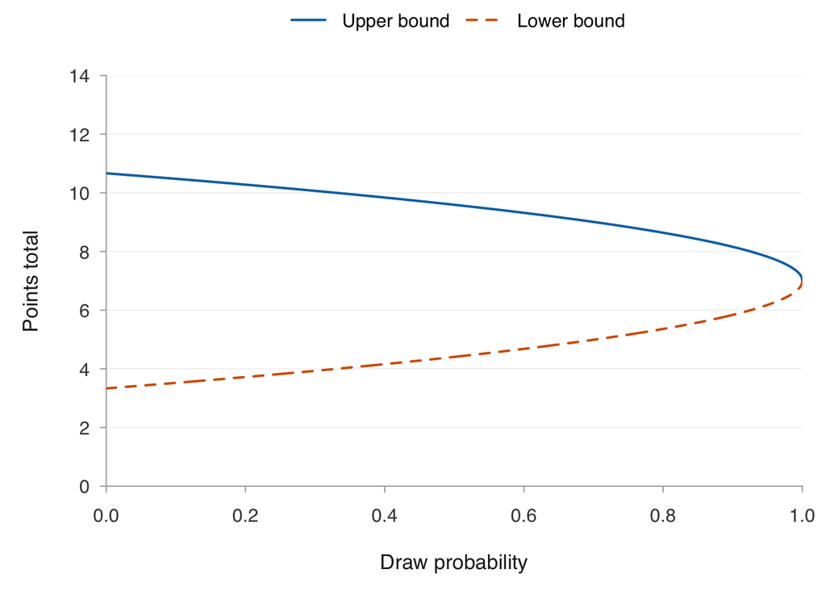

```r
draw_probability <- seq(0, 1, length.out = 1000)
upper <- 14 / 2 + 1.96 * sqrt(14 * (1 - draw_probability) / 4)
lower <- 14 / 2 - 1.96 * sqrt(14 * (1 - draw_probability) / 4)

old_par <- chess_plot_frame(
  draw_probability, ylim = c(0, 14), xlab = "Draw probability",
  x_ticks = seq(0, 1, by = 0.2), y_ticks = seq(0, 14, by = 2)
)
lines(draw_probability, upper, col = chess_colours["blue"], lwd = 2)
lines(draw_probability, lower, col = chess_colours["orange"], lwd = 2, lty = 2)
chess_plot_legend(c("Upper bound", "Lower bound"))
```

```r
par(old_par)
```

### 5.2 Figure 2

Figure 2 of the paper further illustrates the reasonable performance expectations derived from the homogeneous model in Section 2.1, examining how they depend on tournament length rather than the probability of a draw. Under the assumption of independent games between equally strong players, Equation (2) gives the 95% normal-approximation performance bounds
$$\frac{n}{2}\pm1.96\sqrt{\frac{n(1-d)}{4}},$$
where $n$ is the number of games and $d$ is the probability of a draw. Fixing $d=0.794$, the estimate for elite chess reported in the paper, we evaluate these bounds for $n=1,\ldots,50$. The Candidates Tournament, in which each player plays $14$ games, corresponds to $n=14$.

The blue solid curve represents the upper bound and the orange dashed curve the lower bound. While the expected total score grows linearly with $n$, the deviation of either bound from the expected score grows only as $\sqrt{n}$. Consequently, longer tournaments allow for larger absolute deviations from the expected score, but smaller deviations when expressed as a proportion of the total number of games.

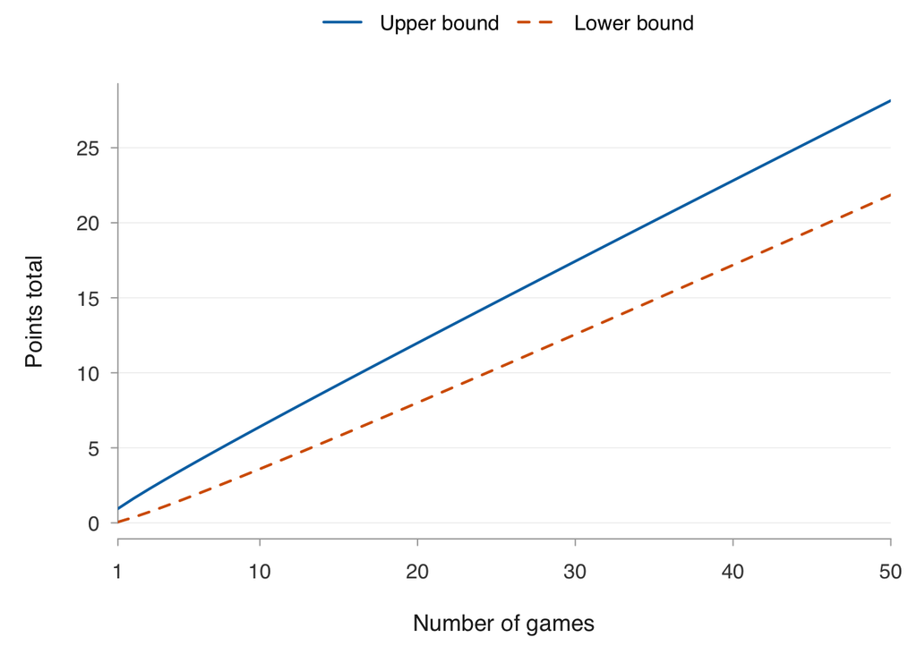

```r
games <- 1:50
draw_probability <- 0.794
upper <- games / 2 + 1.96 * sqrt(games * (1 - draw_probability) / 4)
lower <- games / 2 - 1.96 * sqrt(games * (1 - draw_probability) / 4)

old_par <- chess_plot_frame(
  games, ylim = range(c(lower, upper)), xlab = "Number of games",
  x_ticks = c(1, 10, 20, 30, 40, 50), y_ticks = seq(0, 30, by = 5), yaxs = "r"
)
lines(games, upper, col = chess_colours["blue"], lwd = 2)
lines(games, lower, col = chess_colours["orange"], lwd = 2, lty = 2)
chess_plot_legend(c("Upper bound", "Lower bound"))
```

```r
par(old_par)
```

### 5.3 Figure 3

Figure 3 in the paper illustrates how differences in player strength affect reasonable performance expectations for the Candidates Tournament, extending the homogeneous model of Section 2.1 to the heterogeneous setting of Section 2.2. As before, each player competes in $n=14$ games, with a draw probability $d$. Unlike the homogeneous model, which assumes equally strong opponents, the heterogeneous model introduces $p_X$, the probability that player $X$ wins conditional on a decisive game. The expected score per game and its variance are then
$$\mu=p_X(1-d)+\frac{d}{2},
\qquad
\sigma^2=(1-d)\left[p_X(1-p_X)+d\left(p_X-\frac12\right)^2\right].$$
Under the normal approximation, Equation (4) of the paper gives the corresponding 95% performance bounds
$$n\mu\pm1.96\sqrt{n\sigma^2}\,.$$
These generalise the homogeneous bounds of Equation (2), recovered when $p_X=0.5$.

Figure 3 compares the two models as the draw probability varies from 0 to 1. The blue solid curves represent the homogeneous case ($p_X=0.5$), while the orange dashed curves represent the upper bound for a stronger player ($p_X=0.6$) and the lower bound for a weaker player ($p_X=0.4$). These values are motivated by the Bradley–Terry model with the Elo-inspired strength scale adopted in the paper: the 65-point rating difference reported in Table 3 corresponds to conditional winning probabilities of approximately 0.592 and 0.408, rounded to 0.6 and 0.4 for illustration. The draw probability is assumed independent of player strength.

The comparison demonstrates that accounting for differences in strength expands the range of plausible tournament outcomes, primarily through changes in expected scores rather than increased variance for a given player. As the draw probability increases, decisive games become less frequent and the influence of relative strength diminishes. In the limiting case $d=1$, every game ends in a draw, and all four curves converge to the deterministic total of 7 points. The orange curves therefore illustrate the sensitivity of reasonable performance expectations to player strength, rather than a single prediction interval calibrated to observed tournament results.

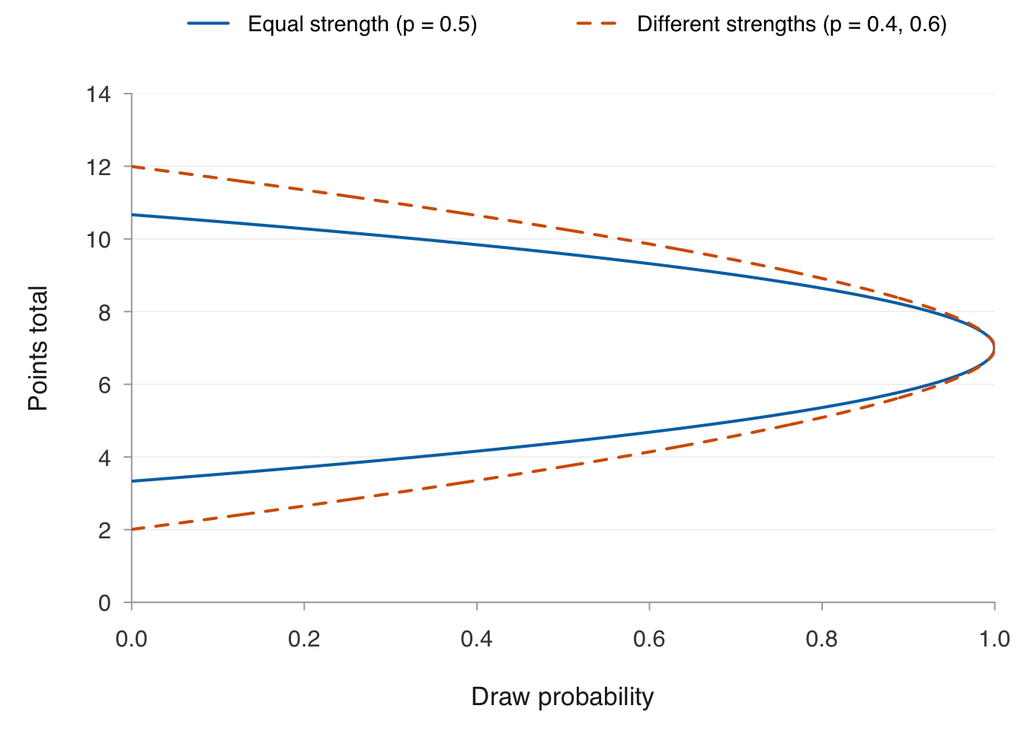

```r
d <- seq(0, 1, length.out = 1000)
homogeneous_upper <- 7 + qnorm(0.975) * sqrt(14 * (1 - d) / 4)
homogeneous_lower <- 7 - qnorm(0.975) * sqrt(14 * (1 - d) / 4)
mu_upper <- 0.6 * (1 - d) + d / 2
mu_lower <- 0.4 * (1 - d) + d / 2
heterogeneous_upper <- 14 * mu_upper + qnorm(0.975) *
  sqrt(pmax(0, 14 * (mu_upper * (1 - mu_upper) - d / 4)))
heterogeneous_lower <- 14 * mu_lower - qnorm(0.975) *
  sqrt(pmax(0, 14 * (mu_lower * (1 - mu_lower) - d / 4)))

old_par <- chess_plot_frame(
  d, ylim = c(0, 14), xlab = "Draw probability",
  x_ticks = seq(0, 1, by = 0.2), y_ticks = seq(0, 14, by = 2)
)
lines(d, homogeneous_upper, col = chess_colours["blue"], lwd = 2)
lines(d, homogeneous_lower, col = chess_colours["blue"], lwd = 2)
lines(d, heterogeneous_upper, col = chess_colours["orange"], lwd = 2, lty = 2)
lines(d, heterogeneous_lower, col = chess_colours["orange"], lwd = 2, lty = 2)
chess_plot_legend(c("Equal strength (p = 0.5)",
                    "Different strengths (p = 0.4, 0.6)"), cex = 0.9)
```

```r
par(old_par)
```

## 6 Cross-country simulations

The following subsections reproduce the Monte Carlo mean team scores and 95% confidence intervals reported in Table 4 of the paper under the normal model (Section 6.1) and the discrete-uniform model (Section 6.2). We also check invalid ranks and the effects of rounding. The sensitivity analysis in Section 6.3 examines whether resolving tied ranks by forward staggering changes these benchmarks or the classifications of the 32 observed teams in Table 5.

The complete cross-country analysis, including the discrete-uniform comparison and all diagnostics, is also saved in cross_country.R. Run it with `Rscript scripts/cross_country.R` from the replication-package folder.

The `MASS` package in `R` is used to generate multivariate normal samples. Here, `B` is the number of Monte Carlo repetitions used to estimate the distribution of one team’s score in a single race, and `n` is the number of runners in the race. We set the random seed to 42 before each simulation so that running the code again gives the same results.

```r
library(MASS)
B <- 1000000  # Monte Carlo repetitions for one team's score in a single race
n <- 224     # Number of runners in the race
seed <- 42   # Random seed used for each model
```

### 6.1 Cross-country: normal model

The paper illustrates the normal model proposed in Section 3 with an application to the 2025 United States universities’ NCAA cross-country championship with $n=224$ competitors. Each team comprises 7 runners, with the combined ranks of its first 5 finishers determining its score. The lowest score wins.

Under the paper’s normal model of competitive balance, the seven teammates’ ranks are approximated jointly by the multivariate normal distribution in equation (10):
$$\mathbf{r}=(r_1,\ldots,r_7)^T\sim N_7(\boldsymbol{\mu},\Sigma) \,.$$
The mean vector and covariance matrix are
$$\boldsymbol{\mu}=\frac{n+1}{2}
\begin{pmatrix}
1\\1\\1\\1\\1\\1\\1
\end{pmatrix}
\,,
\qquad
\Sigma=
\begin{pmatrix}
\sigma^2 & \sigma_{12} & \sigma_{12} & \sigma_{12} & \sigma_{12} & \sigma_{12} & \sigma_{12}\\
\sigma_{12} & \sigma^2 & \sigma_{12} & \sigma_{12} & \sigma_{12} & \sigma_{12} & \sigma_{12}\\
\sigma_{12} & \sigma_{12} & \sigma^2 & \sigma_{12} & \sigma_{12} & \sigma_{12} & \sigma_{12}\\
\sigma_{12} & \sigma_{12} & \sigma_{12} & \sigma^2 & \sigma_{12} & \sigma_{12} & \sigma_{12}\\
\sigma_{12} & \sigma_{12} & \sigma_{12} & \sigma_{12} & \sigma^2 & \sigma_{12} & \sigma_{12}\\
\sigma_{12} & \sigma_{12} & \sigma_{12} & \sigma_{12} & \sigma_{12} & \sigma^2 & \sigma_{12}\\
\sigma_{12} & \sigma_{12} & \sigma_{12} & \sigma_{12} & \sigma_{12} & \sigma_{12} & \sigma^2
\end{pmatrix}
\,,$$
where
$$\sigma=\frac{n+1}{9.8} \,,
\qquad
\sigma_{12}=\frac{n^2-8n+\frac72}{4(4.9)^2} \,.$$
These parameters are specified in equations (5), (6) and (9) in the paper.

The code implements the Monte Carlo procedure described in Section 3.3. For each repetition, it generates a team’s rank vector, sorts all seven entries and selects the five smallest. These five ranks are rounded to the nearest integers and summed. Writing $r_{(1)}\leq\cdots\leq r_{(7)}$ for the sorted ranks, the simulated team score is
$$S=\sum_{j=1}^{5}\operatorname{round}(r_{(j)}) \,.$$
We repeat this procedure independently $B=1{,}000{,}000$ times to estimate the distribution of one team’s score in a single race. The sample mean estimates the expected team score, while the empirical 2.5th and 97.5th percentiles give a central 95% confidence interval. These are the quantities reported in the normal-model row of Table 4.

In the code below, `mvrnorm()` from the `MASS` package generates the `B` rank vectors used in these repetitions by sampling from $N_7(\boldsymbol{\mu},\Sigma)$. It returns a $B\times7$ matrix, with one simulated team’s seven ranks in each row.

```r
# Mean vector and covariance matrix for the seven teammates
mu <- rep((n + 1) / 2, 7)
sigma <- (n + 1) / 9.8
sigma12 <- (n^2 - 8 * n + 7 / 2) / (4 * 4.9^2)
Sigma <- matrix(sigma12, nrow = 7, ncol = 7)
diag(Sigma) <- sigma^2

# Generate B rank vectors, one per row, using a fixed seed
set.seed(seed)
ranks <- mvrnorm(B, mu, Sigma)

# Calculate the team score for each row
# Allocate B entries to store one team score per Monte Carlo repetition
team_scores_normal <- numeric(B)

for (i in seq_len(B)) {
  team_ranks <- ranks[i, ]
  sorted_ranks <- sort(team_ranks)
  scoring_ranks <- sorted_ranks[1:5]
  team_scores_normal[i] <- sum(round(scoring_ranks))
}

# Mean score and endpoints of the central 95% score interval
c(mean = mean(team_scores_normal),
  quantile(team_scores_normal, c(0.025, 0.975)))
```

```
    mean     2.5%    97.5%
552.2525 331.0000 774.0000
```

These results reproduce the normal-model row of Table 4 in the paper. The simulated mean team score is 552.25, and the central 95% score interval runs from 331 to 774 points, given by the 2.5th and 97.5th percentiles of the simulated scores. Lower scores indicate better performance.

### 6.2 Cross-country: discrete-uniform model

Sample seven distinct ranks from 1 to 224 without replacement, then sum the lowest five. This represents a uniformly selected team from the field. Unlike the normal model, it does not assume positively correlated teammates.

```r
# Set the seed for reproducibility
set.seed(seed)

# Simulate B team scores by drawing seven distinct ranks and summing the lowest five
team_scores_uniform <- replicate(B, {
  ranks <- sample.int(n, 7, replace = FALSE)
  sum(sort(ranks)[1:5])
})

# Report the mean and endpoints of the central 95% score interval
c(mean = mean(team_scores_uniform),
  quantile(team_scores_uniform, c(0.025, 0.975)))
```

```
    mean     2.5%    97.5%
422.0608 180.0000 701.0000
```

These results reproduce the discrete-uniform row of Table 4 in the paper. The simulated mean team score is 422.06, and the central 95% score interval runs from 180 to 701 points, given by the 2.5th and 97.5th percentiles of the simulated scores. Lower scores indicate better performance.

### 6.3 Robustness checks: inadmissible ranks and ties

To assess the robustness of the normal-model benchmarks in Table 4, we check the simulated ranks for inadmissible values and ties after rounding. The matrix `ranks`, generated in the normal-model simulation above, contains one simulated team’s seven ranks in each row. Using these same simulated teams, we count individual rounded ranks outside the admissible range 1–224 and teams containing at least one tied rank.

```r
# Initialise the counts of inadmissible ranks and teams containing ties
out_of_range_entries <- 0
teams_with_ties <- 0

for (i in seq_len(B)) {
  # Round the seven ranks for this simulated team
  rounded_ranks <- round(ranks[i, ])
  # Count individual ranks outside the admissible range
  out_of_range_entries <- out_of_range_entries +
    sum(rounded_ranks < 1 | rounded_ranks > n)
  # Count this team once if any rounded ranks are duplicated
  teams_with_ties <- teams_with_ties +
    as.integer(anyDuplicated(rounded_ranks) > 0)
}

# Report the counts and the percentage of teams containing ties
c(inadmissible_rounded_ranks = out_of_range_entries,
  total_ranks = length(ranks),
  teams_with_ties = teams_with_ties,
  percentage_of_teams_with_ties = 100 * teams_with_ties / B)
```

```
   inadmissible_rounded_ranks                   total_ranks
                  6.00000e+00                   7.00000e+06
              teams_with_ties percentage_of_teams_with_ties
                  7.44085e+05                   7.44085e+01
```

In the simulation reported in Section 3.3 of the paper, six rounded ranks fell outside 1–224 and 74.4% of simulated teams had at least one tie. The following sensitivity check assesses whether resolving these ties materially changes the score benchmarks.

We sort and round each team’s seven ranks, then increase each position where necessary to exceed the preceding position. For example, $(20,20,21)$ becomes $(20,21,22)$. We raise the first position to 1 if necessary. If the last position exceeds $n$, we cap it at $n$ and work backwards, lowering earlier positions where necessary to keep the ranks distinct. We then sum the five lowest corrected ranks to obtain the team score.

```r
forward_stagger <- function(team_ranks, n) {
  corrected <- round(sort(team_ranks))
  k <- length(corrected)

  corrected[1] <- max(1, corrected[1])
  for (j in 2:k) {
    corrected[j] <- max(corrected[j], corrected[j - 1] + 1)
  }

  # Keep the ranks within the field while retaining distinct positions
  corrected[k] <- min(n, corrected[k])
  for (j in (k - 1):1) {
    corrected[j] <- min(corrected[j], corrected[j + 1] - 1)
  }
  corrected
}
```

We apply this procedure to the same simulated teams used for the original normal-model benchmark.

```r
team_scores_forward <- numeric(B)

for (i in seq_len(B)) {
  corrected_ranks <- forward_stagger(ranks[i, ], n)
  team_scores_forward[i] <- sum(corrected_ranks[1:5])
}
```

The output below compares the original and corrected benchmarks and reports the changes in the mean score and the two interval endpoints.

```r
original_interval <- quantile(team_scores_normal, c(0.025, 0.975))
corrected_interval <- quantile(team_scores_forward, c(0.025, 0.975))

data.frame(
  method = c("Original rounding (Table 4)", "Ties resolved", "Change"),
  mean = c(mean(team_scores_normal), mean(team_scores_forward),
           mean(team_scores_forward) - mean(team_scores_normal)),
  lower = c(original_interval[1], corrected_interval[1],
            corrected_interval[1] - original_interval[1]),
  upper = c(original_interval[2], corrected_interval[2],
            corrected_interval[2] - original_interval[2]),
  row.names = NULL
)
```

```
                       method       mean lower upper
1 Original rounding (Table 4) 552.252475   331   774
2               Ties resolved 553.376279   332   775
3                      Change   1.123804     1     1
```

As reported in Section 3.3, resolving ties increased the mean score by approximately 1.1 points and both endpoints of the central 95% score interval by one point.

Finally, we check whether using the corrected interval changes the performance classifications of the 32 observed teams in Table 5. Lower scores indicate better performance: a score below the lower endpoint is above expectations, a score above the upper endpoint is below expectations, and scores at or between the endpoints are within expectations.

```r
ncaa_scores <- read.csv("data/ncaa_2025_team_scores.csv", fileEncoding = "UTF-8")
observed_scores <- ncaa_scores$score

classify_scores <- function(scores, interval) {
  ifelse(scores < interval[1], "Above expectations",
         ifelse(scores > interval[2], "Below expectations", "Within expectations"))
}

original_classification <- classify_scores(observed_scores, original_interval)
corrected_classification <- classify_scores(observed_scores, corrected_interval)

c(teams_checked = length(observed_scores),
  changed_classifications = sum(original_classification != corrected_classification))
```

```
          teams_checked changed_classifications
                     32                       0
```

Section 3.3 reports that all 32 teams retained their classifications. Although ties were frequent, resolving them had little effect on the benchmarks and left the conclusions for the observed teams unchanged.

## 8 Citation

If you use this notebook, please cite the accompanying paper listed in the introduction. Download the BibTeX citation or copy it below:

```
@article{2026-fry-ste-fan-ser-sma,
  author = {Fry, John and Stevenson, Freddie and Fanzon, Silvio
            and Serbera, Jean-Philippe and Smales, Thomas},
  title = {Quantifying reasonable performance expectations in
           (non-traditional) sports},
  year = {2026},
  note = {Forthcoming}
}
```

## 9 License & attribution

This notebook and its code are licensed under the [Creative Commons Attribution-NonCommercial 4.0 International License (CC BY-NC 4.0)](https://creativecommons.org/licenses/by-nc/4.0/). You may share and adapt them for noncommercial purposes with appropriate attribution, a link to the licence, and an indication of any changes. Please credit the accompanying paper and Silvio Fanzon and John Fry as the notebook authors. Third-party data remain subject to their source terms.